# Ecological forecasting in R

Tutorial 3: model and forecast evaluation

Nicholas Clark, School of Veterinary Science, University of Queensland[^1]

## Exercises and associated data

The data and modelling objects created in this notebook can be downloaded directly to save computational time.

Users who wish to complete the exercises can download a small template `R` script. Assuming you have already downloaded the data objects above, this script will load all data objects so that the steps used to create them are not necessary to tackle the exercises.

## Load libraries and time series data

This tutorial relates to content covered in [Lecture 4](https://nicholasjclark.github.io/physalia-forecasting-course/day3/lecture_4_slidedeck), and relies on the following packages for manipulating data, shaping time series, fitting dynamic regression models and plotting:

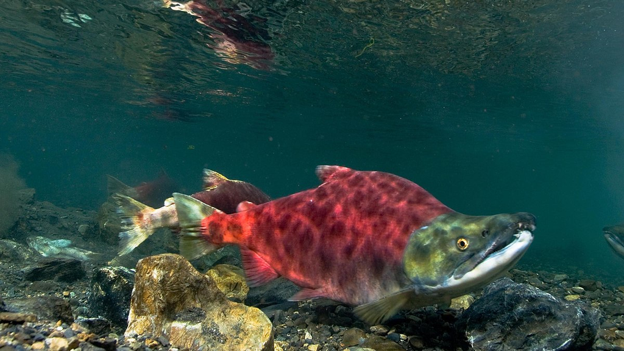

A sockeye salmon (*Oncorhynchus nerka*) in spawning colours; photo Wikimedia Commons

```r
library(dplyr)
library(mvgam)
library(marginaleffects)
library(tidybayes)
library(ggplot2); theme_set(theme_classic())
```

The data we will use for this tutorial is spawner-recruit data for sockeye salmon (*Oncorhynchus nerka*) from the Bristol Bay region in Southwest Alaska. Commercial fishermen in Alaska target this important species using seines and gillnets for fresh or frozen fillet sales and canning. Records for the rivers in Bristol Bay span the years 1952-2005, and are maintained within the RAM Legacy Stock Assessment Database. Spawner estimates originated from Bristol Bay Area Annual Management Reports from the Alaska Department of Fish and Game, and are based on in-river spawner counts (including both tower counts and aerial surveys). Age-specific catch rates were calculated from records of catch and escapement according to age class. These data were used to determine the number of recruits in each year.

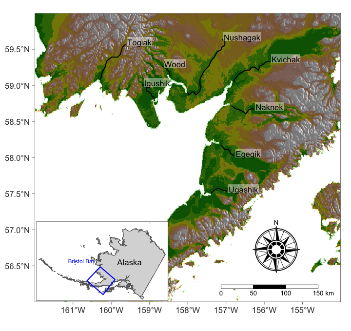

Map of the rivers in Bristol Bay, Alaska sampled for sockeye spawners; photo courtesy of Holmes, Ward and Scheuerell, https://atsa-es.github.io/

### Manipulating data for modelling

Below we process the data, keeping observations for a single river and taking $log(spawners_{t})$ to use as the offset in our models. We also retain two possibly important covariates, `pdo_winter_t2` and `pdo_summer_t2`. These variables, representing the Pacific Decadal Oscillation (PDO) during the salmon’s first year in the ocean (i.e. 2 years prior to sampling), are widely believed to reflect “bottlenecks” to salmon survival in their first year.

```r
# access the data from the ATSA Github site
load(url('https://github.com/atsa-es/atsalibrary/raw/master/data/sockeye.RData'))
sockeye %>%

  # Remove any previous grouping structures
  dplyr::ungroup() %>%

  # select the target river
  dplyr::filter(region == "KVICHAK") %>%

  # filter the data to only include years when number of spawners
  # was estimated, as this will be used as the offset
  dplyr::filter(!is.na(spawners)) %>%

  # log the spawners variable to use as an appropriate offset
  dplyr::mutate(log_spawners = log(spawners)) %>%

  # add a 'time' variable
  dplyr::mutate(time = dplyr::row_number()) %>%

  # add a series variable (as a factor)
  dplyr::mutate(series = as.factor('sockeye')) %>%

  # keep variables of interest
  dplyr::select(time, series, log_spawners,
                recruits, pdo_summer_t2, pdo_winter_t2) -> model_data
```

Check the data structure

```r
head(model_data)
```

```
## # A tibble: 6 × 6
##    time series  log_spawners recruits pdo_summer_t2 pdo_winter_t2
##   <int> <fct>          <dbl>    <dbl>         <dbl>         <dbl>
## 1     1 sockeye         9.15    39000         -0.5          -0.31
## 2     2 sockeye         7.95     4090         -2.36         -1.78
## 3     3 sockeye         6.28      289         -1.48         -2.14
## 4     4 sockeye         6.52      547          0.58          0
## 5     5 sockeye         9.59    55300          1.05          0.68
## 6     6 sockeye         8.22     3500         -0.22          0.77
```

```r
dplyr::glimpse(model_data)
```

```
## Rows: 50
## Columns: 6
## $ time          <int> 1, 2, 3, 4, 5, 6, 7, 8, 9, 10, 11, 12, 13, 14, 15, 16, 1…
## $ series        <fct> sockeye, sockeye, sockeye, sockeye, sockeye, sockeye, so…
## $ log_spawners  <dbl> 9.152711, 7.951559, 6.282267, 6.522093, 9.588777, 8.2187…
## $ recruits      <dbl> 39000, 4090, 289, 547, 55300, 3500, 5360, 1120, 5750, 45…
## $ pdo_summer_t2 <dbl> -0.50, -2.36, -1.48, 0.58, 1.05, -0.22, 0.01, -0.73, -1.…
## $ pdo_winter_t2 <dbl> -0.31, -1.78, -2.14, 0.00, 0.68, 0.77, 0.07, -0.42, -0.8…
```

Visualize the data as a heatmap to get a sense of where any `NA`s are distributed (`NA`s are shown as red bars in the below plot)

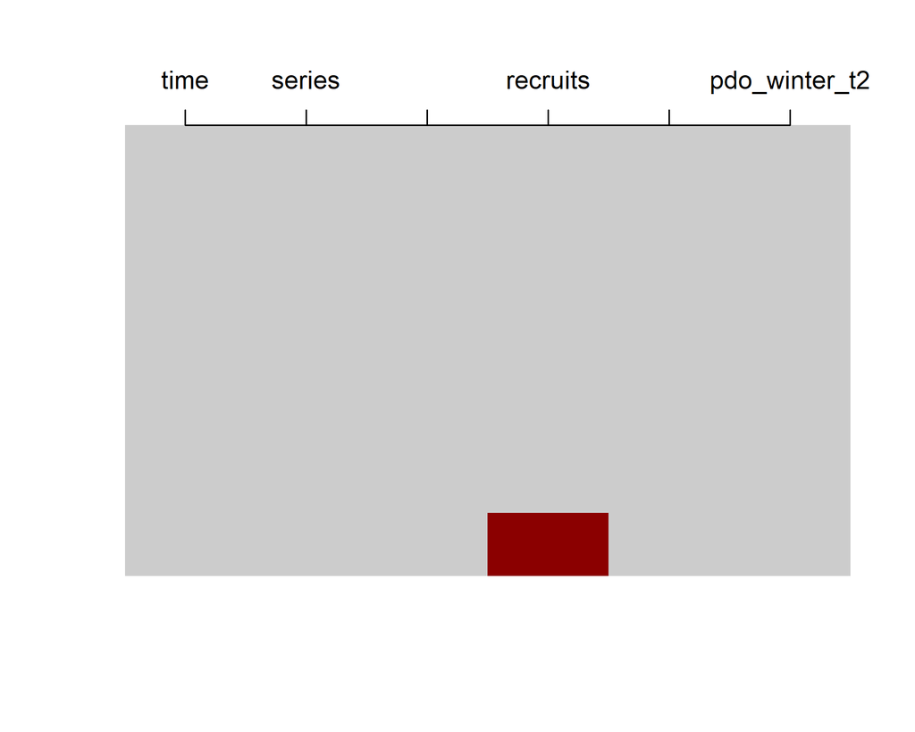

```r
image(
  is.na(t(model_data %>%
            dplyr::arrange(dplyr::desc(time)))), axes = F,
  col = c('grey80', 'darkred')
)
axis(3,
     at = seq(0,1, len = NCOL(model_data)),
     labels = colnames(model_data))
```

Plot properties of the time series, which indicate some overdispersion in the recruit count values that we’ll have to address

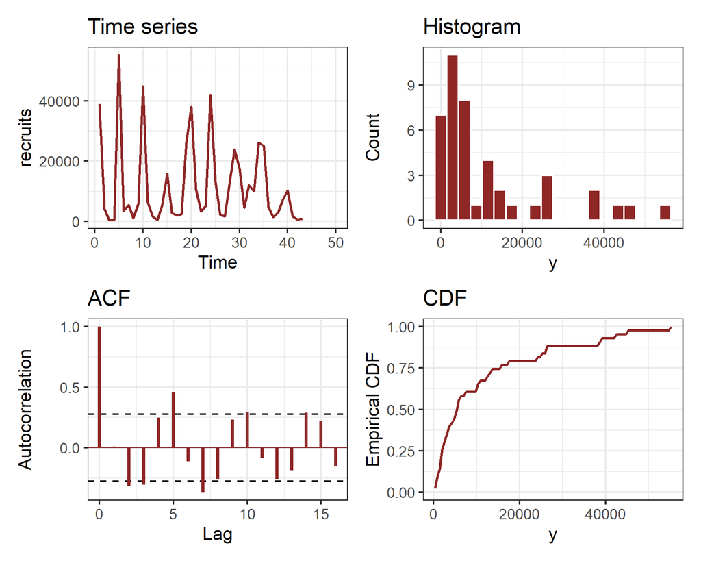

## Posterior simulation in `mvgam`

We will fit a number of models to these data to showcase the various methods that are available to us for evaluating and comparing dynamic GLMs / GAMs. We begin with a model that does not include a dynamic component, as this is always a useful starting point. It also allows us to highlight another useful feature of GLMs / GAMs when modelling count data, as we can include an offset variable that allows us to model *rates of interest*.

Sometimes it is more relevant to model the rate an event occurs per some underlying unit. For example, in epidemiological modelling the interest is often in understanding the number of disease cases per population. But we never get to *observe* this rate directly. An offset allows us to model the underlying rate by [algebraically accounting for variation in the number of possible counts in each observation unit](https://stats.stackexchange.com/questions/11182/when-to-use-an-offset-in-a-poisson-regression). This works naturally in models that use a log link function, such as the Poisson and Negative Binomial models. Including an offset is usually straightforward in most `R` modelling software, and indeed this is the case in `mvgam` as well. Here we fit a model with no trend and Poisson observations, including an offset of the `log_spawners` variable that we calculated above so we can estimate the *rate of recruitment per spawner*. Our first model includes smooth functions of `pdo_winter_t2` and `pdo_summer_t2` (including an interaction among the two), along with an offset of `log_spawners` in the linear predictor. As in previous tutorials, only 250 samples per chain are used to keep the size of the resulting object small (though we’d always want to use more samples in a real analysis). Note that this is not a classic density-dependent stock-recruitment model such as the [Ricker or Beverton Holt models](http://derekogle.com/fishR/examples/oldFishRVignettes/StockRecruit.pdf). Rather, this model very simplistically assumes recruits can increase without bound as a function of the number of spawners.

```r
model1 <- mvgam(
  recruits ~ offset(log_spawners) +
    s(pdo_winter_t2,
      k = 3,
      bs = 'cr') +
    s(pdo_summer_t2,
      k = 3,
      bs = 'cr') +
    ti(pdo_winter_t2,
       pdo_summer_t2,
       k = 3,
       bs = 'cr'),
  family = poisson(),
  trend_model = 'None',
  data = model_data,
  samples = 250
)
```

The model summary is shown below, which indicates there are no major sampling issues to worry about. It also suggests that the interaction among the two covariates is highly wiggly and important in the model (as are the main effects)

```r
summary(model1)
```

```
## GAM formula:
## recruits ~ offset(log_spawners) + s(pdo_winter_t2, k = 3, bs = "cr") +
##     s(pdo_summer_t2, k = 3, bs = "cr") + ti(pdo_winter_t2, pdo_summer_t2,
##     k = 3, bs = "cr")
##
## Family:
## poisson
##
## Link function:
## log
##
## Trend model:
## None
##
## N series:
## 1
##
## N timepoints:
## 50
##
## Status:
## Fitted using Stan
## 4 chains, each with iter = 1000; warmup = 750; thin = 1
## Total post-warmup draws = 1000
##
##
## GAM coefficient (beta) estimates:
##                                   2.5%  50% 97.5% Rhat n_eff
## (Intercept)                       -1.6 -1.5  -1.5    1   298
## s(pdo_winter_t2).1                 6.1  6.2   6.3    1   374
## s(pdo_winter_t2).2                -1.6 -1.6  -1.5    1   549
## s(pdo_summer_t2).1                 5.0  5.1   5.2    1   345
## s(pdo_summer_t2).2                -5.8 -5.7  -5.7    1   397
## ti(pdo_winter_t2,pdo_summer_t2).1  5.4  5.5   5.6    1   428
## ti(pdo_winter_t2,pdo_summer_t2).2 27.0 27.0  28.0    1   380
## ti(pdo_winter_t2,pdo_summer_t2).3 12.0 12.0  13.0    1   474
## ti(pdo_winter_t2,pdo_summer_t2).4 16.0 16.0  16.0    1   308
##
## Approximate significance of GAM smooths:
##                                   edf Ref.df Chi.sq p-value
## s(pdo_winter_t2)                1.686      2   18.3  <2e-16 ***
## s(pdo_summer_t2)                0.984      2   26.6  <2e-16 ***
## ti(pdo_winter_t2,pdo_summer_t2) 3.516      4   28.0  <2e-16 ***
## ---
## Signif. codes:  0 '***' 0.001 '**' 0.01 '*' 0.05 '.' 0.1 ' ' 1
##
## Stan MCMC diagnostics:
## ✔ No issues with effective samples per iteration
## ✔ Rhat looks good for all parameters
## ✔ No issues with divergences
## ✔ No issues with maximum tree depth
##
## Samples were drawn using sampling(hmc). For each parameter, n_eff is a
##   crude measure of effective sample size, and Rhat is the potential scale
##   reduction factor on split MCMC chains (at convergence, Rhat = 1)
##
## Use how_to_cite() to get started describing this model
```

The inclusion of the offset is important if we wish to make predictions on the scale of the observations. This is because there will be no regression coefficient assigned to this variable (it’s coefficient is fixed at 1). If you wish to manually make predictions, you’ll need to take care to include the offset. This is returned as an attribute of the linear predictor matrix when we call `predict.gam` on the underlying `mgcv` model:

```r
lpmatrix <- predict(model1$mgcv_model, type = 'lpmatrix')
attr(lpmatrix, 'model.offset')
```

```
##  [1]  9.152711  7.951559  6.282267  6.522093  9.588777  8.218787  7.855545
##  [8]  5.826000  6.863803 10.098232  8.237479  8.077137  7.847763  9.034796
## [15]  9.539644  7.779049  6.917706  5.424950  8.396155  9.480368  7.585789
## [22]  7.200425  8.330864  9.323669  9.769956  7.467371  7.038784  8.180321
## [29]  9.259131  8.883224  7.073270  8.711114  8.311398  9.026418  8.849371
## [36]  8.347590  8.461680  8.301522  9.028818  9.210340  7.279319  7.313220
## [43]  7.740664  8.732305  7.512071  7.003065  6.556778  7.432484  8.612503
## [50]  7.749322
```

`mvgam` makes this process straightforward using the `predict.mvgam()`, which is then used by many other functions in the package including `plot_predictions()`, `draw()`, `hindcast()` and `forecast()`. It is also used by `conditional_effects()`, which is one of the first functions you will likely use after fitting a model in `mvgam`. This function acts as a wrapper to the more flexible `plot_predictions()` and can give a quick overview of the “main” effects in a model’s regression formulae. It displays all combinations up to two-way interactions. See `?conditional_effects.mvgam` for guidance.

```r
conditional_effects(
  model1,
  type = 'link'
)
```

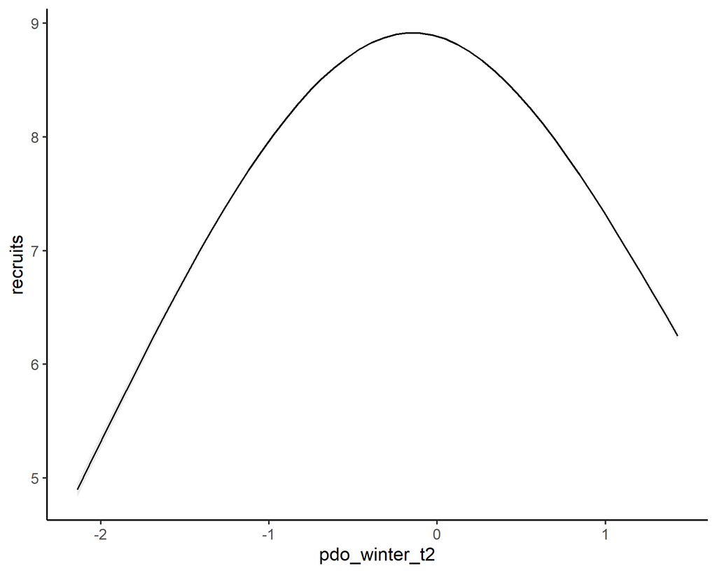

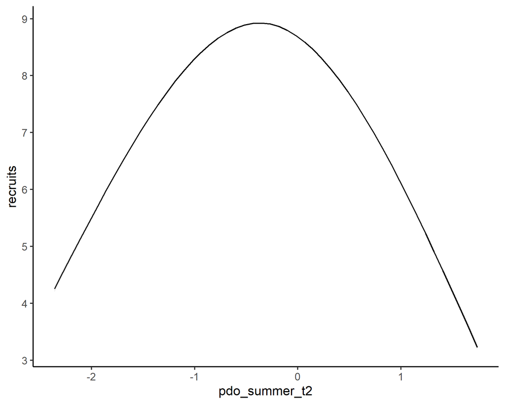

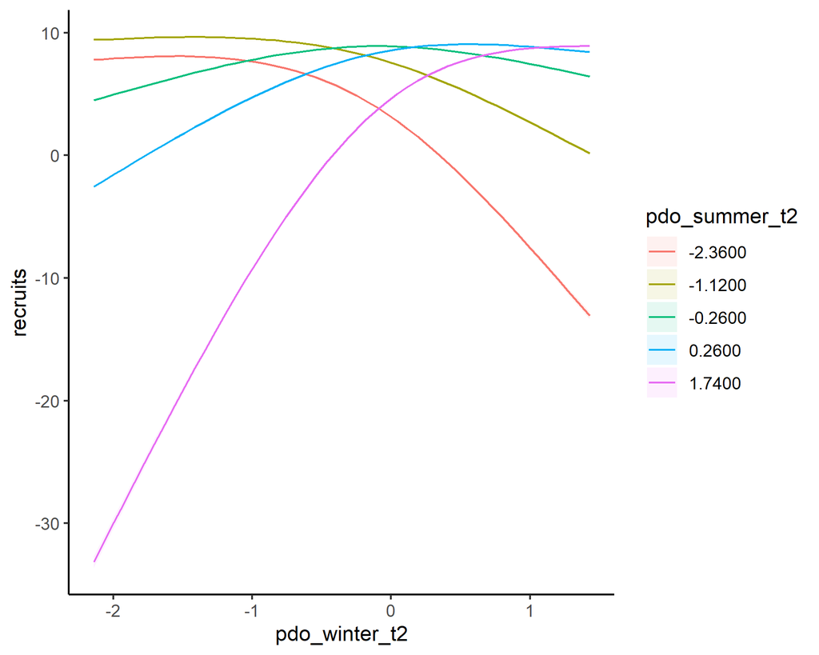

I usually recommend you use `type = 'link'` or `type = 'expected'` when plotting these, as the default `type = 'response'` can sometimes make it hard to see patterns for certain response families. But because we used a Poisson family, the patterns won’t change too much between the default `type = 'response'` and `type = 'expected'` (apart from wider uncertainty bands):

```r
conditional_effects(
  model1,
  type = 'expected'
)
```

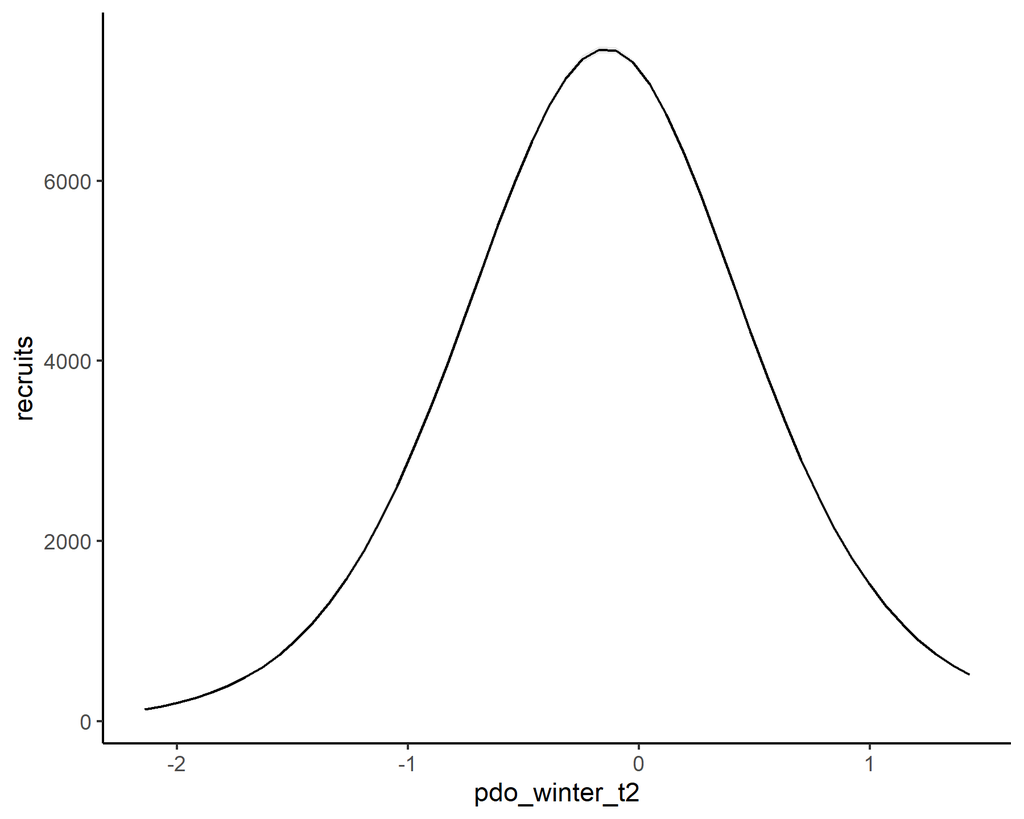

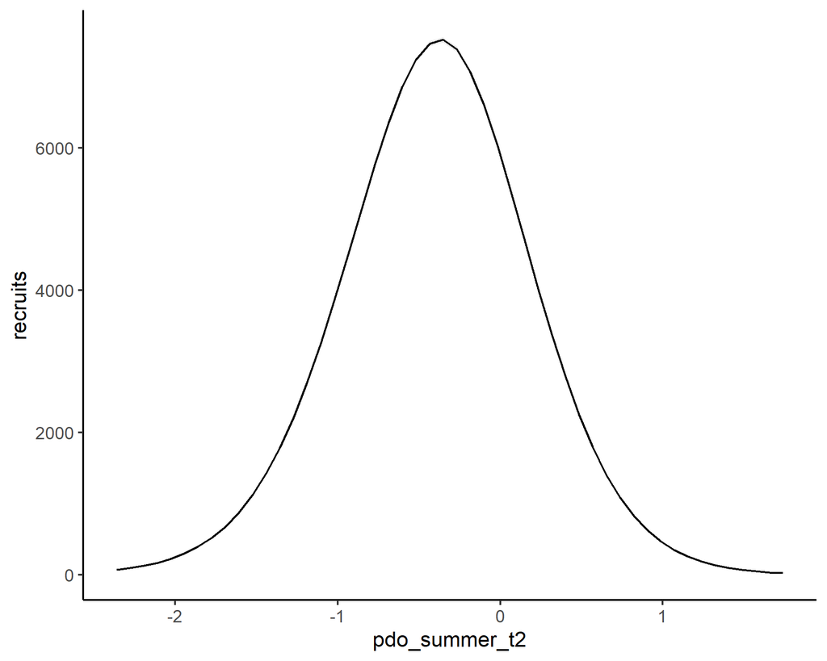

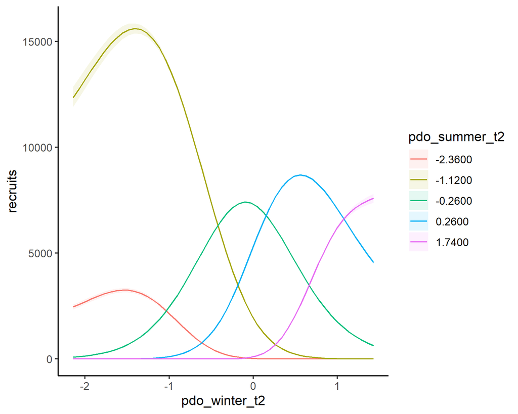

```r
conditional_effects(
  model1,
  type = 'response'
)
```

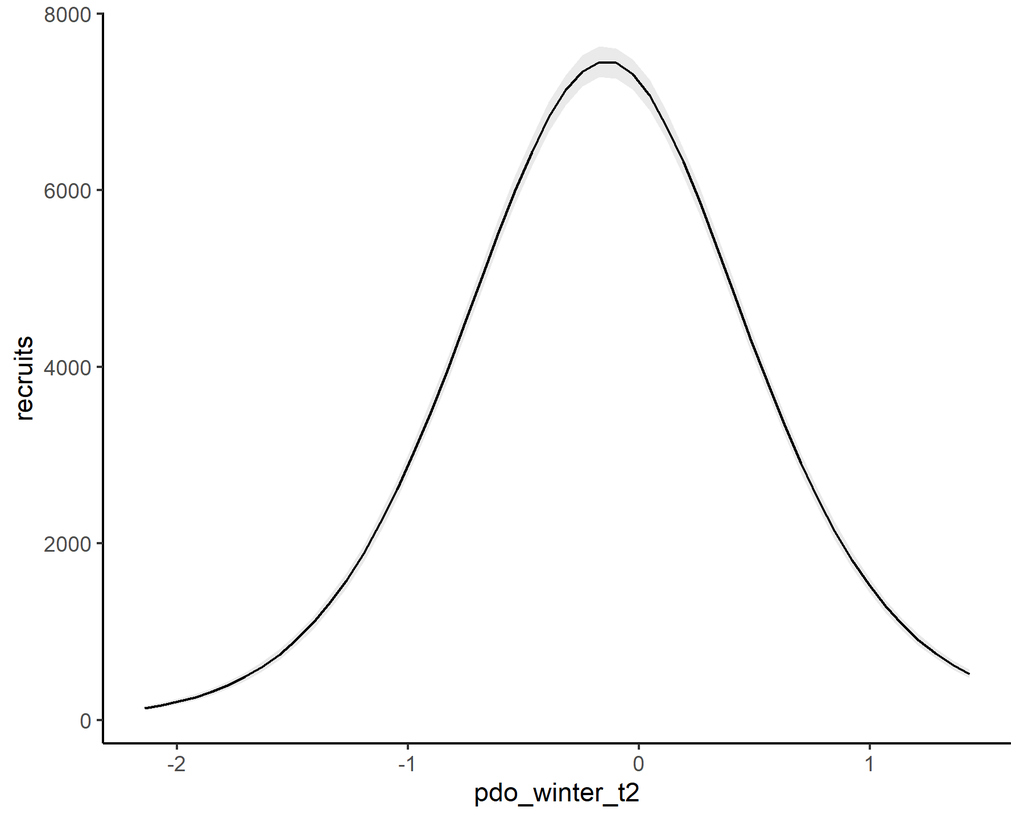

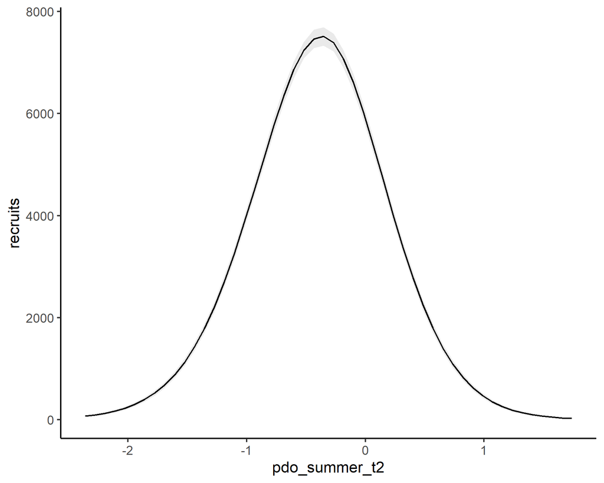

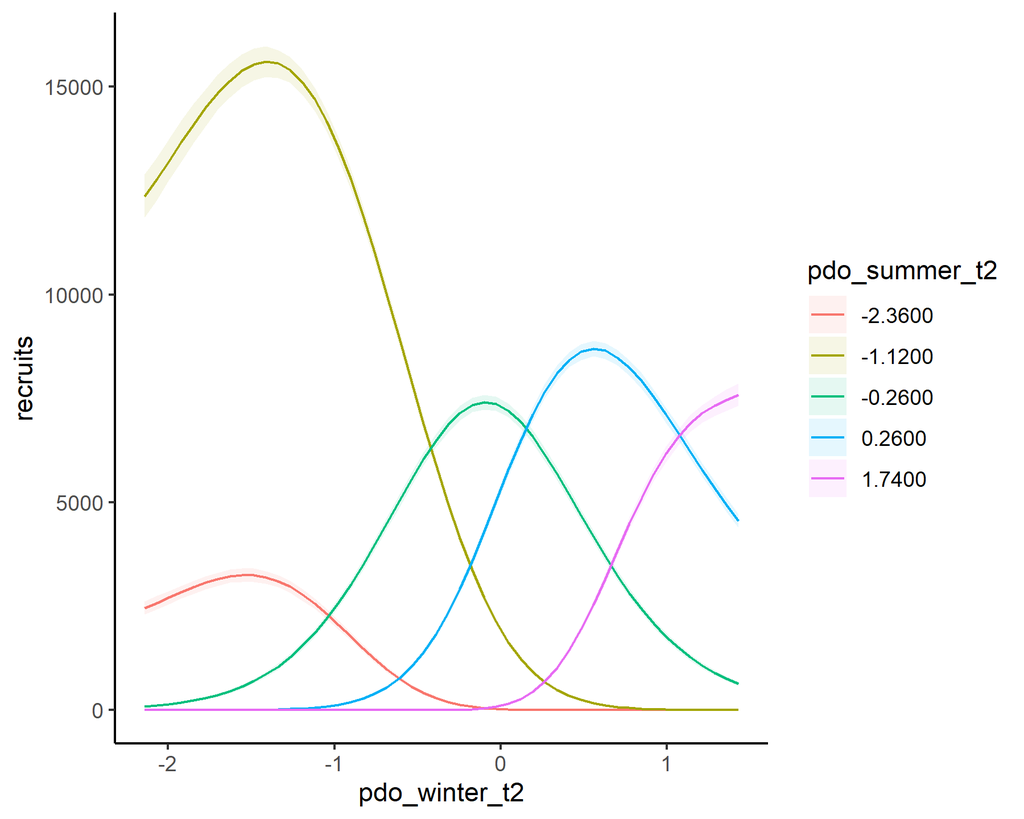

```r
datagrid(
  pdo_winter_t2 = range,
  model = model1
)
```

```
##   log_spawners pdo_summer_t2 time  series pdo_winter_t2 rowid
## 1     8.067752       -0.3032   26 sockeye         -2.14     1
## 2     8.067752       -0.3032   26 sockeye          1.43     2
```

We can make this grid as simple or as fancy as we want. Here we will provide a set sequence of values for `pdo_winter_t2`:

```r
datagrid(
  pdo_winter_t2 = c(-2, -1, 0, 1, 2),
  model = model1
)
```

```
##   log_spawners pdo_summer_t2 time  series pdo_winter_t2 rowid
## 1     8.067752       -0.3032   26 sockeye            -2     1
## 2     8.067752       -0.3032   26 sockeye            -1     2
## 3     8.067752       -0.3032   26 sockeye             0     3
## 4     8.067752       -0.3032   26 sockeye             1     4
## 5     8.067752       -0.3032   26 sockeye             2     5
```

This same logic can easily be extended to multiple predictors:

```r
datagrid(
  pdo_winter_t2 = c(-2, -1, 0, 1, 2),
  pdo_summer_t2 = c(-3, 3),
  model = model1
)
```

```
##    log_spawners time  series pdo_winter_t2 pdo_summer_t2 rowid
## 1      8.067752   26 sockeye            -2            -3     1
## 2      8.067752   26 sockeye            -2             3     2
## 3      8.067752   26 sockeye            -1            -3     3
## 4      8.067752   26 sockeye            -1             3     4
## 5      8.067752   26 sockeye             0            -3     5
## 6      8.067752   26 sockeye             0             3     6
## 7      8.067752   26 sockeye             1            -3     7
## 8      8.067752   26 sockeye             1             3     8
## 9      8.067752   26 sockeye             2            -3     9
## 10     8.067752   26 sockeye             2             3    10
```

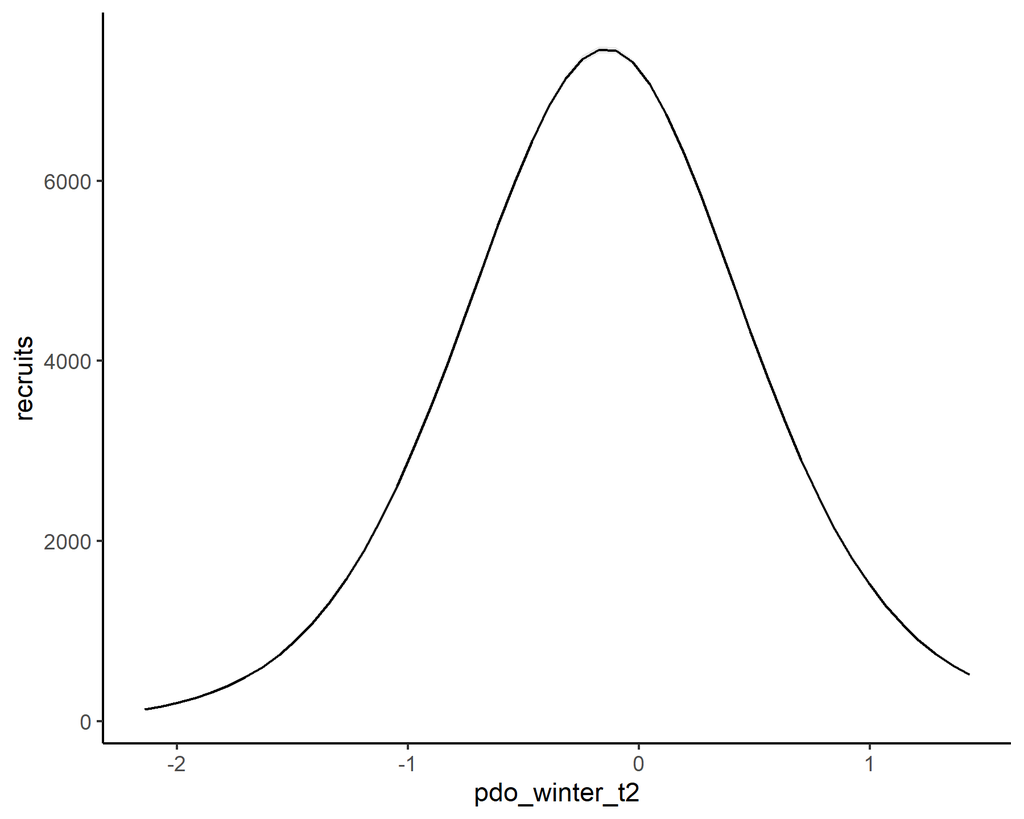

```r
plot_predictions(
  model1,
  condition = 'pdo_winter_t2',
  type = 'expected'
)
```

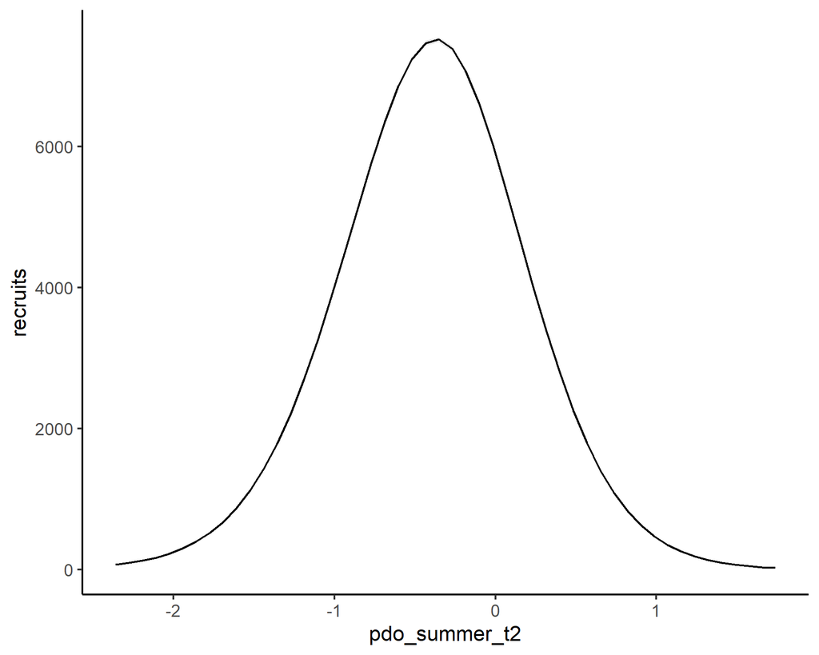

```r
plot_predictions(
  model1,
  condition = 'pdo_summer_t2',
  type = 'expected'
)
```

Supplying more than one covariate to the `condition` argument will set up more in-depth visualisations:

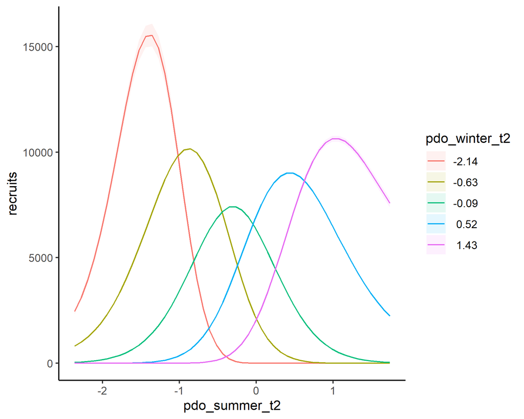

```r
plot_predictions(
  model1,
  condition = c('pdo_summer_t2',
                'pdo_winter_t2'),
  type = 'expected'
)
```

Alternatively, we can supply covariates to the `by` argument. This will only used those values that were actually observed in the original data, rather than making a sequence of fake values. This can be very handy for looking at hindcast distributions from some of our models by passing `time` to the `by` argument. Adding a non-zero value for the `points` argument will show the observed data points

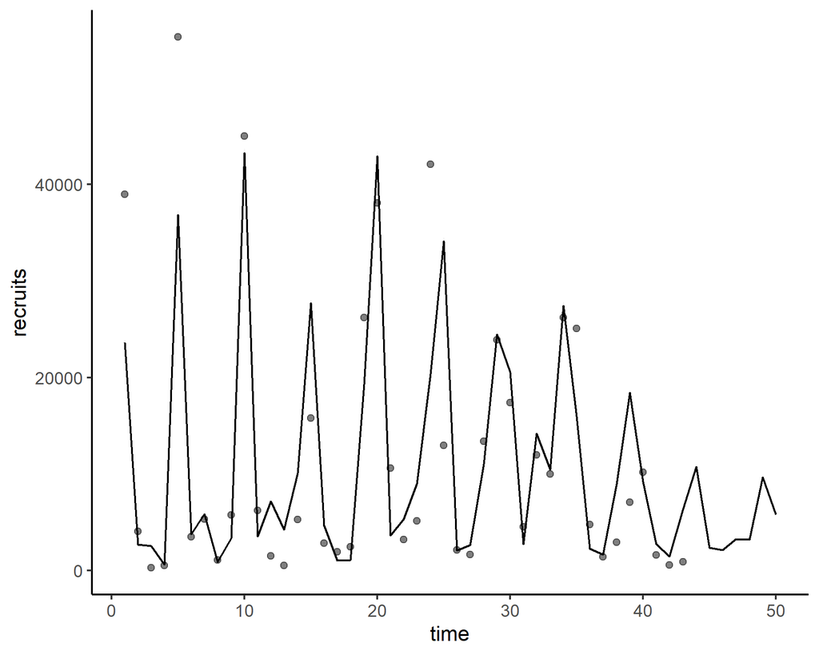

```r
plot_predictions(
  model1,
  by = 'time',
  points = 0.5
)
```

The `plot_slopes()` function is also highly useful, in this case for understanding how a nonlinear effect changes over the space of a covariate (i.e. what is the first derivative of the function over a grid of covariate values).

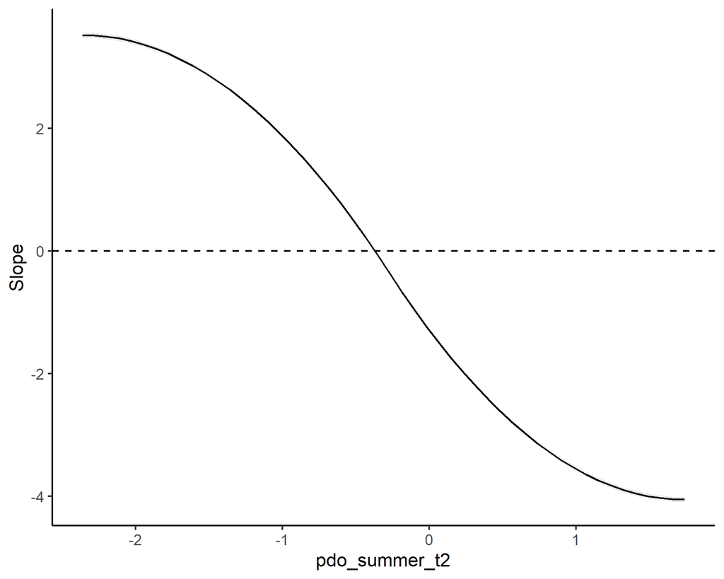

```r
plot_slopes(
  model1,
  variables = 'pdo_summer_t2',
  condition = 'pdo_summer_t2',
  type = 'link'
) +
  geom_hline(yintercept = 0,
             linetype = 'dashed')
```

```r
# take draws from the model that compute the average comparison between
# spawners recorded at 5,000 vs 3,000 (be sure to log first!)
post_contrasts <- avg_comparisons(
  model1,
  variables = list(log_spawners = log(c(3000, 5000))),
  type = 'expected'
) %>%
  posterior_draws()
head(post_contrasts)
```

```
##   drawid     draw         term                            contrast estimate
## 1      1 4438.660 log_spawners 8.51719319141624 - 8.00636756765025 4430.429
## 2      2 4433.804 log_spawners 8.51719319141624 - 8.00636756765025 4430.429
## 3      3 4435.292 log_spawners 8.51719319141624 - 8.00636756765025 4430.429
## 4      4 4444.133 log_spawners 8.51719319141624 - 8.00636756765025 4430.429
## 5      5 4427.345 log_spawners 8.51719319141624 - 8.00636756765025 4430.429
## 6      6 4431.674 log_spawners 8.51719319141624 - 8.00636756765025 4430.429
##   conf.low conf.high predicted_lo predicted_hi predicted tmp_idx
## 1 4415.562  4445.988     7505.689     12509.48   23617.9       1
## 2 4415.562  4445.988     7505.689     12509.48   23617.9       1
## 3 4415.562  4445.988     7505.689     12509.48   23617.9       1
## 4 4415.562  4445.988     7505.689     12509.48   23617.9       1
## 5 4415.562  4445.988     7505.689     12509.48   23617.9       1
## 6 4415.562  4445.988     7505.689     12509.48   23617.9       1
```

Each row of the returned object gives us one posterior draw of this comparison. We can plot the distribution of these comparisons using the `tidybayes` package:

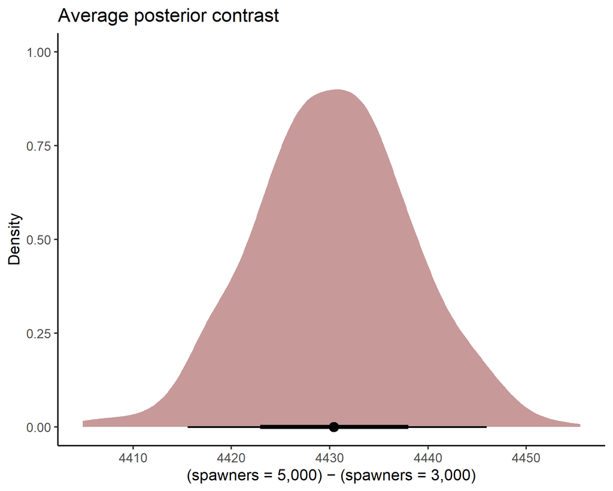

```r
# use the resulting posterior draw object to plot a density of the
# posterior contrasts
post_contrasts %>%
  ggplot(aes(x = draw)) +

  # use the stat_halfeye function from tidybayes for a nice visual
  stat_halfeye(fill = "#C79999") +
  labs(
    x = "(spawners = 5,000) − (spawners = 3,000)",
    y = "Density",
    title = "Average posterior contrast"
  ) +
  theme_classic()
```

### Posterior predictive checks

Posterior predictive checks are useful for understanding how well your model can capture particular features of your observed data. In `mvgam`, the `pp_check()` function is particularly helpful as it relies on the very broad range of checking functions that are available in `bayesplot`. For example, we can plot a density kernel of our observed counts and overlay simulated kernels from our model. These simulated kernels are generated using `predict.mvgam()`, so they are informative for all `mvgam` models (regardless of whether or not the model included dynamic components).

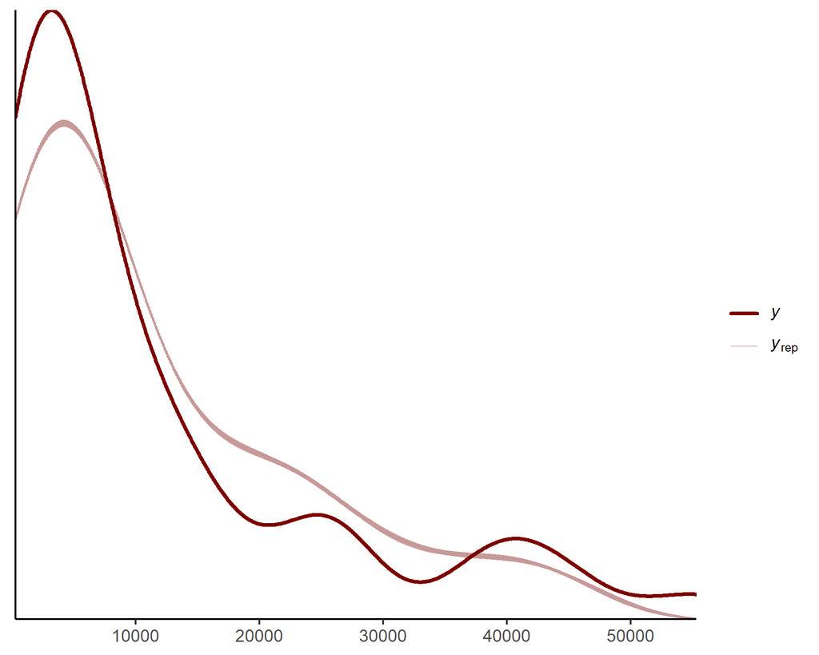

```r
pp_check(
  model1,
  type = 'dens_overlay',
  ndraws = 100
)
```

This model is not really capturing the shape of the observed data. We can confirm this behaviour by comparing observed vs simulated CDFs. What else might we need to do to improve this model?

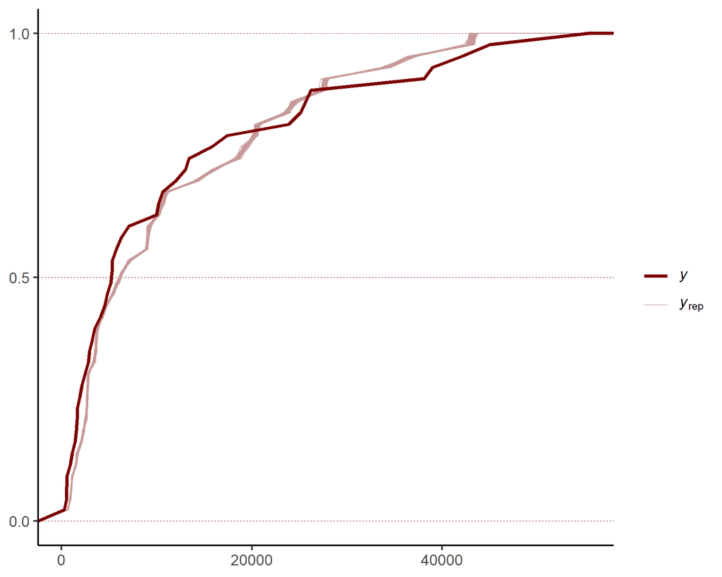

```r
pp_check(
  model1,
  type = 'ecdf_overlay',
  ndraws = 100
)
```

There are many other types of posterior predictive checks that can be implemented, and it is highly recommended that you design some to suit your own specific needs (i.e., what aspect(s) of the data are you most concerned with your model being able to adequately capture?). See `?mvgam::ppc_check` for details of other kinds of plots you can make.

Of course we should look more closely at the residuals for any unmodelled temporal autocorrelation

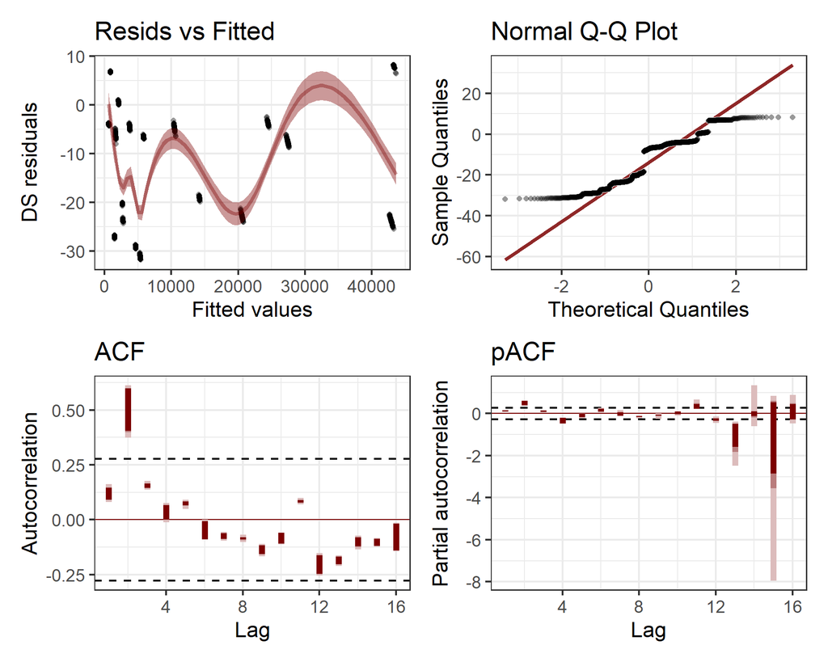

```r
plot(
  model1,
  type = 'residuals'
)
```

### Model expansion

Back to the modelling strategy. There are still some patterns in the residuals, including substantial autocorrelation and an apparent mis-specification of the dispersion in the data. We need a dynamic model to capture this autocorrelation, so we will add an AR1 model for the residuals. But we also need to think about the dispersion in the data. A Negative Binomial may be better here, as it can handle count values that distribute beyond what a Poisson can handle.

```r
model2 <- mvgam(
  recruits ~
    offset(log_spawners) +
    s(pdo_winter_t2,
      k = 3,
      bs = 'cr') +
    s(pdo_summer_t2,
      k = 3,
      bs = 'cr') +
    ti(pdo_winter_t2,
       pdo_summer_t2,
       k = 3,
       bs = 'cr'),,
  family = nb(),
  trend_model = AR(),
  noncentred = TRUE,
  data = model_data
)
```

Because this model has a dynamic trend component, it is worth quickly revisiting the differences between the `predict.mvgam()` function and the `hindcast.mvgam()` / `forecast.mvgam()` functions. First, we investigate how ignoring the uncertainty in the trend component changes the predictions. In this step, we calculate predictions for the observed time period in two ways: first we average over the uncertainty from the latent trend (using `process_error = TRUE`). This will essentially give us a prediction where we include the random effect of the latent process model, but assume that we have a different possible sample from that random effect distribution at each time point. Second, we use `process_error = FALSE` to give predictions that essentially ignore the random effects from the latent process. Plotting both of these together shows how our prediction uncertainty changes when we include the uncertainty in the dynamic trend component. A crucial detail to understand here is that the `predict.mvgam()` only uses the covariates from the model formulae, so in this case it does not account for the actual ‘times’ of the data. Rather it assumes the dynamic process has reached stationarity and simply samples from the following distribution for the trend: $z_t \sim Normal(0, \sigma_{error})$

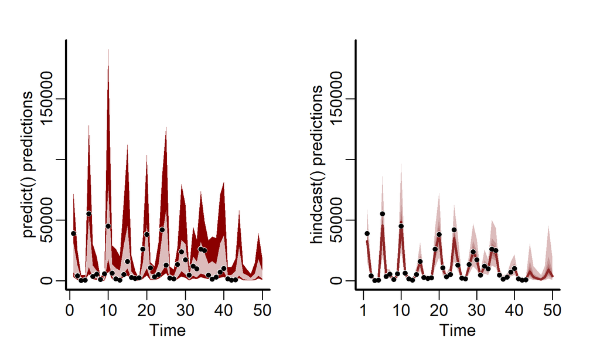

```r
# calculate predictions for the training data by including
# the dynamic process uncertainty without estimating the actual
# latent states
ypreds <- predict(
  model2,
  type = 'response',
  process_error = TRUE,
  summary = FALSE
)

# calculate 95% empirical quantiles of predictions
cred <- sapply(
  1:NCOL(ypreds),
  function(n)
    quantile(ypreds[,n],
             probs = c(0.025, 0.975),
             na.rm = T)
)
pred_vals <- 1:NCOL(ypreds)

# graphical plotting parameters
layout(matrix(1:2, ncol = 2))
par(mar = c(2.5, 2.3, 2, 2),
    oma = c(1, 1, 0, 0),
    mgp = c(1.5, 0.5, 0))

# plot credible intervals
plot(
  1,
  type = "n",
  bty = 'L',
  xlab = 'Time',
  ylab = 'predict() predictions',
  xlim = c(min(pred_vals),
           max(pred_vals)),
  ylim = c(min(cred, na.rm = T),
           max(cred, na.rm = T))
)
polygon(
  c(pred_vals, rev(pred_vals)),
  c(cred[1,], rev(cred[2,])),
  col = 'darkred',
  border = NA
)

# now repeat, but this time ignore uncertainty in the dynamic component
ypreds2 <- predict(
  model2,
  type = 'response',
  process_error = FALSE,
  summary = FALSE
)
cred2 <- sapply(
  1:NCOL(ypreds),
  function(n)
    quantile(ypreds2[,n],
             probs = c(0.025, 0.975),
             na.rm = T)
)

# overlay these predictions as a lighter colour
polygon(
  c(pred_vals, rev(pred_vals)),
  c(cred2[1,], rev(cred2[2,])),
  col = "#DCBCBC",
  border = NA
)

# overlay the actual observations as well
points(
  model_data$recruits,
  pch = 16,
  cex = 0.8,
  col = 'white'
)
points(
  model_data$recruits,
  pch = 16, cex = 0.65
)
box(bty = 'l', lwd = 2)

# now plot the actual hindcasts, which did not assume the process was
# stationary but instead modelled the latent states over the training time.
# use the same y-axis limits to see how these plots differ
plot_mvgam_fc(
  model2,
  ylim = c(min(cred, na.rm = T),
           max(cred, na.rm = T)),
  ylab = 'hindcast() predictions'
)
```

```r
layout(1)
```

As you can see, the predictions differ. The `plot_mvgam_fc()` function, which uses the same prediction steps as `hindcast()` and `forecast()` functions, *uses the actual estimates of the latent temporal states*. These predictions will nearly always “fit the data better”, but they might not be as useful for scenario-planning. Sometimes we’d rather get a sense of how predictions might change *on average* if some external conditions changed, for example if temperature were to increase by x degrees or if we were to sample from a new group for a random effect. For exploring these types of scenarios, the prediction-based functions (i.e. `predict()`, `plot_predictions()`, `conditional_effects()`, `pp_check()` etc…) are more useful because they *do not use the actual estimates of the latent states*.

### Exercises

1. Plot a histogram of `model1`’s posterior intercept coefficients $\alpha$. Use `?mvgam::as.data.frame.mvgam` for guidance
2. Plot a scatterplot of `recruits` vs `log_spawners` using the supplies `model_data`. Take a few notes on whether you think our primary modelling assumption, that the number of log(`recruits`) scales linearly with number of `log_spawners`, is justified.

**Check here if you’re having trouble extracting the intercept posterior**

```r
# Replace the ? with the correct value(s)
# check names of variables that can be extracted
vars_available <- variables(model1)

# we are interested in the observation model coefficients
vars_available$observation_betas

# extract the intercepts using the as.data.frame.mvgam function
# you will have two options for extracting this variable. first, you
# can use the alias
alphas <- as.data.frame(model1, variable = ?)

# alternatively, use the original name
alphas <- as.data.frame(model1, variable = ?)

# plot a histogram
hist(alphas[,1], xlab = expression(alpha),
     main = '', col = 'darkred', border = 'white')
```

## Comparing dynamic models

Now on to the topic of model comparisons. Plot Dunn-Smyth residuals for this dynamic model to see that there is no more autocorrelation

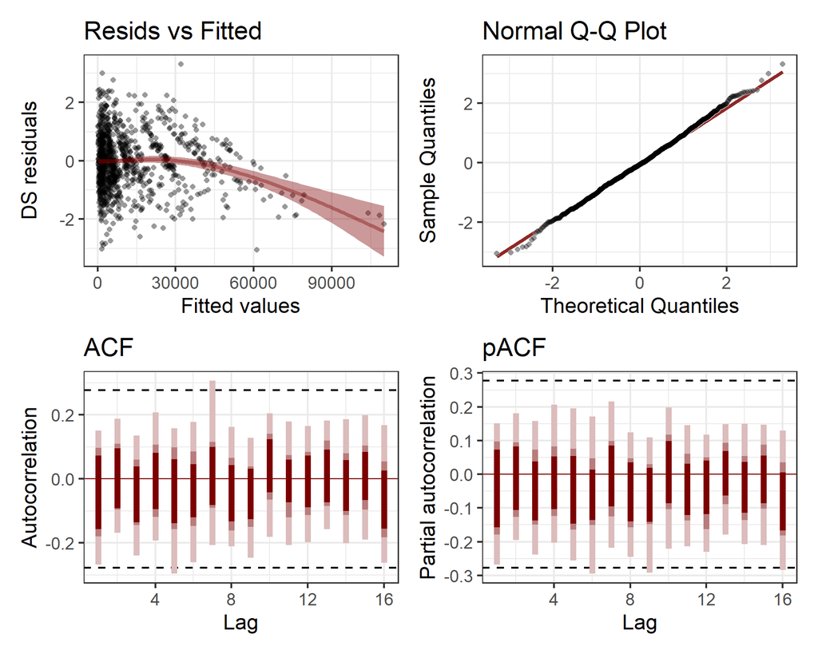

```r
plot(
  model2,
  type = 'residuals'
)
```

However we must be cautious interpreting these residuals because the AR1 trend model is extremely flexible. The in-sample fits can sometimes be nearly perfect, meaning the residuals will very often look excellent! We can confirm this behaviour by inspecting hindcasts

```
## No non-missing values in test_observations; cannot calculate forecast score
```

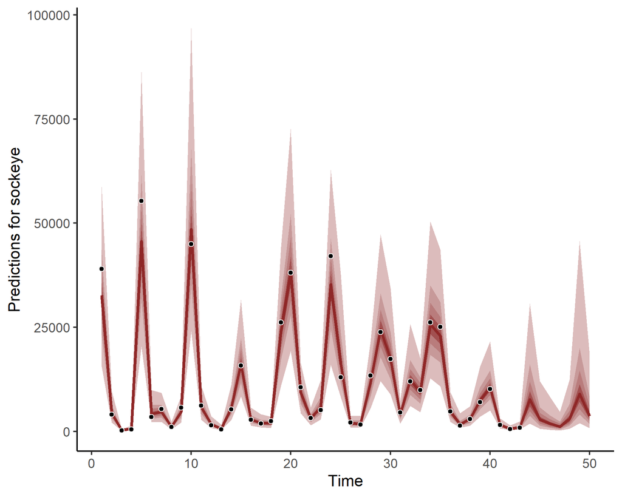

```r
hcs <- hindcast(model2)
plot(hcs)
```

But PPCs can still give valid insights into model inadequacy:

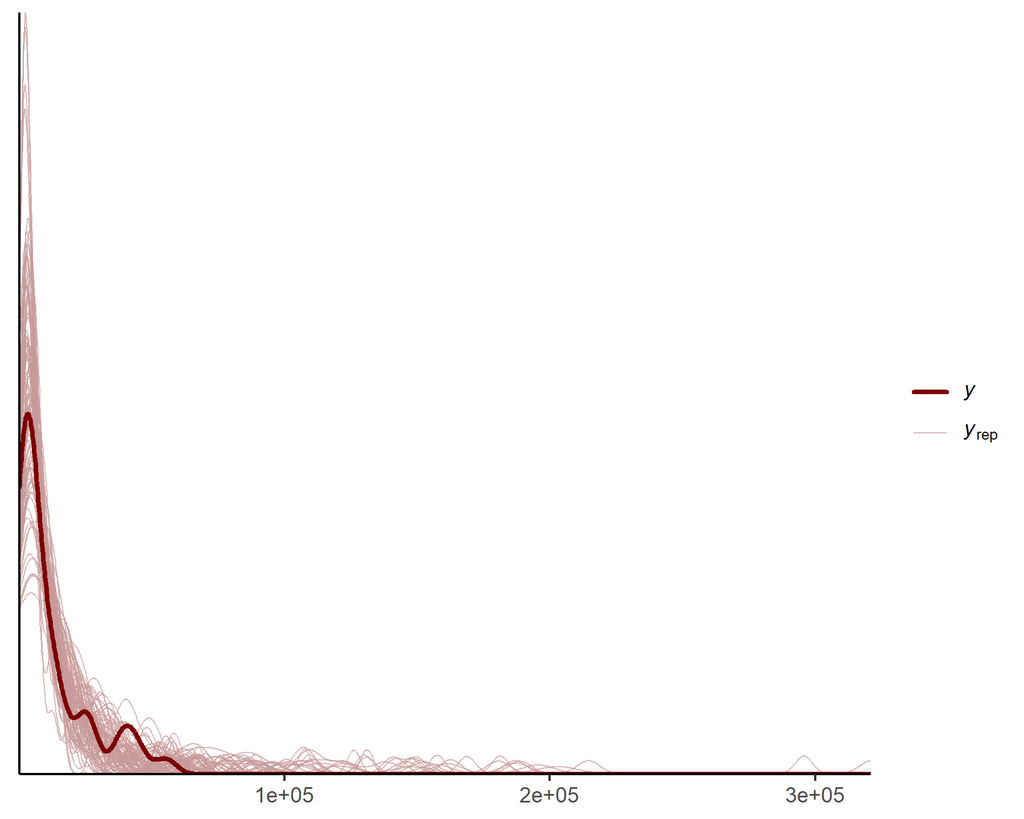

```r
pp_check(
  model2,
  type = 'dens_overlay',
  ndraws = 100
)
```

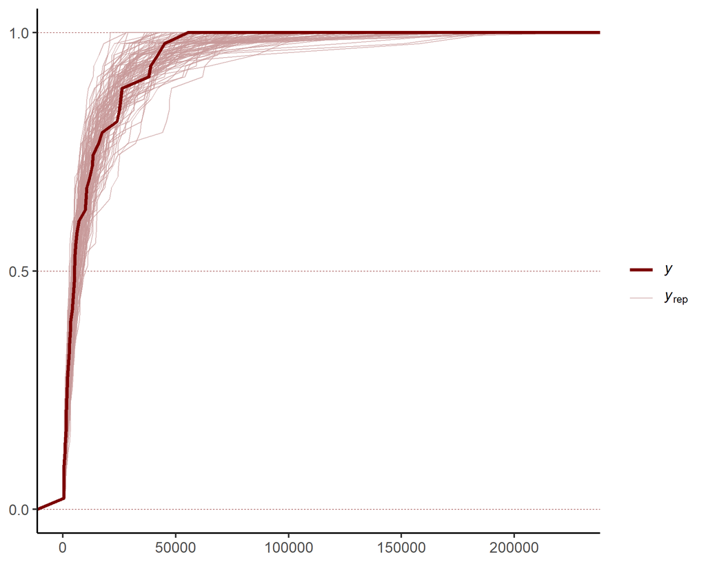

```r
pp_check(
  model2,
  type = 'ecdf_overlay',
  ndraws = 100
)
```

These plots show that the model clearly gives a better fit to the data compared to the Poisson model above. But there are some more worrying and pressing matters we can address with this model. Inspect the summary to see what I mean:

```r
summary(model2)
```

```
## GAM formula:
## recruits ~ offset(log_spawners) + s(pdo_winter_t2, k = 3, bs = "cr") +
##     s(pdo_summer_t2, k = 3, bs = "cr") + ti(pdo_winter_t2, pdo_summer_t2,
##     k = 3, bs = "cr")
##
## Family:
## negative binomial
##
## Link function:
## log
##
## Trend model:
## AR()
##
##
## N series:
## 1
##
## N timepoints:
## 50
##
## Status:
## Fitted using Stan
## 4 chains, each with iter = 1000; warmup = 500; thin = 1
## Total post-warmup draws = 2000
##
##
## Observation dispersion parameter estimates:
##        2.5% 50% 97.5% Rhat n_eff
## phi[1]  3.9  12    47 1.03   137
##
## GAM coefficient (beta) estimates:
##                                    2.5%    50% 97.5% Rhat n_eff
## (Intercept)                        0.21  0.560  0.89 1.02   391
## s(pdo_winter_t2).1                -0.51 -0.016  0.48 1.00  1162
## s(pdo_winter_t2).2                -0.44  0.027  0.48 1.00   866
## s(pdo_summer_t2).1                -0.64 -0.089  0.38 1.01   547
## s(pdo_summer_t2).2                -0.45  0.017  0.47 1.00  1011
## ti(pdo_winter_t2,pdo_summer_t2).1 -0.66 -0.038  0.49 1.00   507
## ti(pdo_winter_t2,pdo_summer_t2).2 -0.66 -0.015  0.52 1.00   561
```

[output cut: 11 more lines]

```
## ar1[1]   0.25 0.63  0.97 1.01   450
## sigma[1] 0.47 0.68  0.94 1.03   153
##
## Stan MCMC diagnostics:
## ✔ No issues with effective samples per iteration
## ✖ Rhats above 1.05 found for some parameters
##     Use pairs() and mcmc_plot() to investigate
## ✔ No issues with divergences
## ✔ No issues with maximum tree depth
##
## Samples were drawn using sampling(hmc). For each parameter, n_eff is a
##   crude measure of effective sample size, and Rhat is the potential scale
##   reduction factor on split MCMC chains (at convergence, Rhat = 1)
##
## Use how_to_cite() to get started describing this model
```

The HMC sampler is telling us there are some issues when trying to implement both a flexible latent dynamic process AND an overdispersion parameter. Both of these components are competing to capture the extra dispersion in the observations, leading to low effective sample sizes and poor convergence for the overdispersion parameter $\phi$. As the `summary()` suggests, it is useful to look at estimates for these parameters using the diagnostic functions `pairs()` and `mcmc_plot()`:

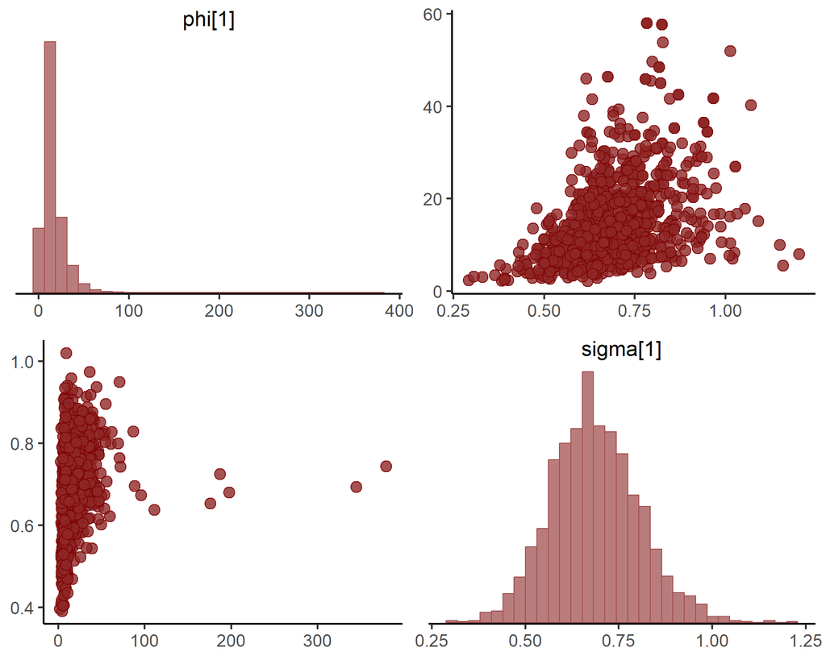

```r
pairs(
  model2,
  variable = c('phi',
               'sigma'),
  regex = TRUE
)
```

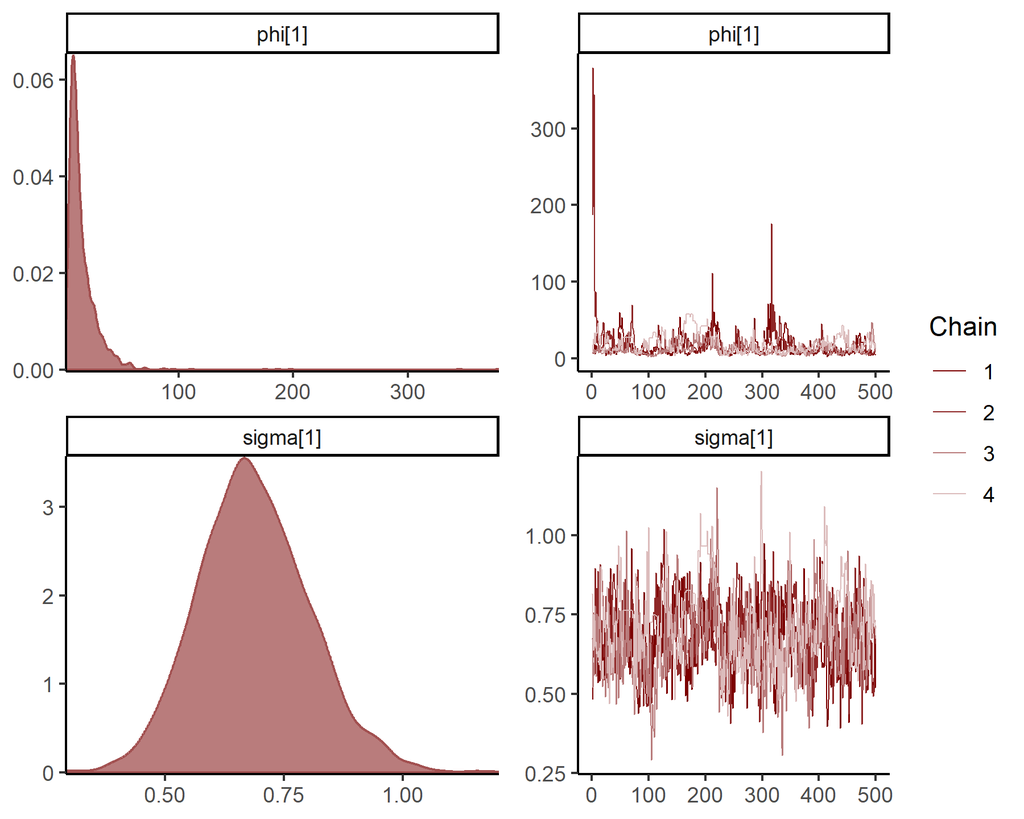

```r
mcmc_plot(
  model2,
  variable = c('phi',
               'sigma'),
  regex = TRUE,
  type = 'combo'
)
```

We now have several options:

1. Use containment priors to restrict one or both of the processes (i.e. pull the overdispersion parameter towards very large values to make the observations behave like a Poisson a priori)
2. Keep the Negative Binomial observation model and use a smooth trend, such as a Gaussian Process or a Piecewise Logistic
3. Drop the Negative Binomial observation model (using a Poisson instead) and use a flexible Autoregressive trend

Here we will illustrate the latter two options. First, we try the Negative Binomial observation model with a smooth Piecewise Logistic function for the trend. This trend model can be useful for population dynamics as it follows one of ecology’s classic population growth models. However, we must supply a value for the carrying capacity of the trend process. Here we will assume the maximum value the logistic growth trend could take is the same as the maximum value that the latent AR1 process from `model2` took. Note that we also must suppress the intercept in the formula because piecewise trends have their own intercept parameters.

```r
model_data$cap <- exp(
  max(hindcast(model2,
               type = 'trend')$hindcasts$sockeye)
)
```

```r
model3 <- mvgam(
  recruits ~
    offset(log_spawners) +
    s(pdo_winter_t2,
      k = 3,
      bs = 'cr') +
    s(pdo_summer_t2,
      k = 3,
      bs = 'cr') +
    ti(pdo_winter_t2,
       pdo_summer_t2,
       k = 3,
       bs = 'cr') - 1,
  family = nb(),
  trend_model = PW(growth = 'logistic'),
  data = model_data
)
```

Next we use a Poisson observation model with a AR1 trend

```r
model4 <- mvgam(
  recruits ~
    offset(log_spawners) +
    s(pdo_winter_t2,
      k = 3,
      bs = 'cr') +
    s(pdo_summer_t2,
      k = 3,
      bs = 'cr') +
    ti(pdo_winter_t2,
       pdo_summer_t2,
       k = 3,
       bs = 'cr'),
  family = poisson(),
  trend_model = AR(),
  noncentred = TRUE,
  data = model_data
)
```

```r
summary(model3)
```

```
## GAM formula:
## recruits ~ s(pdo_winter_t2, k = 3, bs = "cr") + s(pdo_summer_t2,
##     k = 3, bs = "cr") + ti(pdo_winter_t2, pdo_summer_t2, k = 3,
##     bs = "cr") + offset(log_spawners) - 1
##
## Family:
## negative binomial
##
## Link function:
## log
##
## Trend model:
## PW(growth = "logistic")
##
##
## N series:
## 1
##
## N timepoints:
## 50
##
## Status:
## Fitted using Stan
## 4 chains, each with iter = 1000; warmup = 500; thin = 1
## Total post-warmup draws = 2000
##
##
## Observation dispersion parameter estimates:
##        2.5% 50% 97.5% Rhat n_eff
## phi[1]  1.2 1.8   2.7    1  1237
##
## GAM coefficient (beta) estimates:
##                                    2.5%     50% 97.5% Rhat n_eff
## s(pdo_winter_t2).1                -0.67 -0.0770  0.40 1.00  1220
## s(pdo_winter_t2).2                -0.37  0.0790  0.62 1.00   769
## s(pdo_summer_t2).1                -0.74 -0.0820  0.44 1.00   744
## s(pdo_summer_t2).2                -0.50 -0.0072  0.49 1.00   815
## ti(pdo_winter_t2,pdo_summer_t2).1 -1.50 -0.0830  0.45 1.03   103
## ti(pdo_winter_t2,pdo_summer_t2).2 -2.00 -0.0330  0.58 1.04    92
## ti(pdo_winter_t2,pdo_summer_t2).3 -0.50  0.0700  1.60 1.04   105
```

[output cut: 12 more lines]

```
## Latent trend offset estimates:
##            2.5%  50% 97.5% Rhat n_eff
## m_trend[1] -2.2 -0.3   1.6    1  2250
##
## Stan MCMC diagnostics:
## ✔ No issues with effective samples per iteration
## ✔ Rhat looks good for all parameters
## ✔ No issues with divergences
## ✔ No issues with maximum tree depth
##
## Samples were drawn using sampling(hmc). For each parameter, n_eff is a
##   crude measure of effective sample size, and Rhat is the potential scale
##   reduction factor on split MCMC chains (at convergence, Rhat = 1)
##
## Use how_to_cite() to get started describing this model
```

```r
summary(model4)
```

```
## GAM formula:
## recruits ~ offset(log_spawners) + s(pdo_winter_t2, k = 3, bs = "cr") +
##     s(pdo_summer_t2, k = 3, bs = "cr") + ti(pdo_winter_t2, pdo_summer_t2,
##     k = 3, bs = "cr")
##
## Family:
## poisson
##
## Link function:
## log
##
## Trend model:
## AR()
##
##
## N series:
## 1
##
## N timepoints:
## 50
##
## Status:
## Fitted using Stan
## 4 chains, each with iter = 1000; warmup = 500; thin = 1
## Total post-warmup draws = 2000
##
##
## GAM coefficient (beta) estimates:
##                                    2.5%     50% 97.5% Rhat n_eff
## (Intercept)                        0.18  0.4900  0.82 1.01   301
## s(pdo_winter_t2).1                -0.52 -0.0100  0.47 1.00  1041
## s(pdo_winter_t2).2                -0.47  0.0300  0.47 1.00  1069
## s(pdo_summer_t2).1                -0.70 -0.1100  0.31 1.01   811
## s(pdo_summer_t2).2                -0.49  0.0043  0.48 1.00   645
## ti(pdo_winter_t2,pdo_summer_t2).1 -0.73 -0.0340  0.45 1.02   302
## ti(pdo_winter_t2,pdo_summer_t2).2 -0.77 -0.0073  0.56 1.02   219
## ti(pdo_winter_t2,pdo_summer_t2).3 -0.42  0.0490  0.77 1.01   260
## ti(pdo_winter_t2,pdo_summer_t2).4 -0.40  0.0870  0.93 1.02   241
##
## Approximate significance of GAM smooths:
##                                      edf Ref.df Chi.sq p-value
## s(pdo_winter_t2)                0.003532      2   0.03    0.98
## s(pdo_summer_t2)                0.000275      2   0.42    0.90
## ti(pdo_winter_t2,pdo_summer_t2) 0.000134      4   0.72    0.99
##
## Latent trend parameter AR estimates:
##          2.5%  50% 97.5% Rhat n_eff
## ar1[1]   0.22 0.48  0.67 1.01   380
## sigma[1] 0.64 0.78  0.99 1.02   409
##
## Stan MCMC diagnostics:
## ✔ No issues with effective samples per iteration
## ✔ Rhat looks good for all parameters
## ✔ No issues with divergences
## ✖ 764 of 2000 iterations saturated the maximum tree depth of 10 (38.2%)
##     Try a larger max_treedepth to avoid saturation
##
## Samples were drawn using sampling(hmc). For each parameter, n_eff is a
##   crude measure of effective sample size, and Rhat is the potential scale
##   reduction factor on split MCMC chains (at convergence, Rhat = 1)
##
## Use how_to_cite() to get started describing this model
```

But hindcasts and trend estimates are very different for the two models:

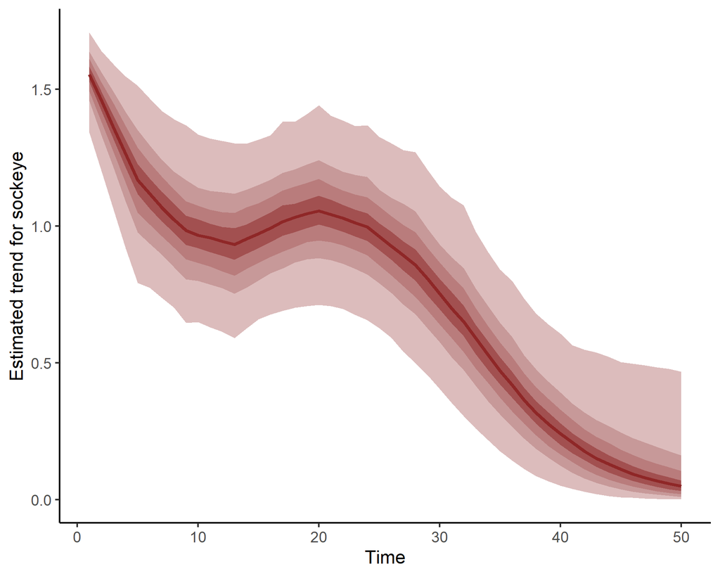

```r
plot(
  model3,
  type = 'trend'
)
```